# Case_Study1

Emre Can Çamcı

2023-03-31

## Ask Phase

- Business task is to understand how annual members and casual riders use Cyclistic bikes differently

## Prepare Phase

- To analyze the yearly trips from 2022 data has been downloaded from this [link](https://divvy-tripdata.s3.amazonaws.com/index.html) and has been made available by Motivate International Inc. under this [licence](https://ride.divvybikes.com/data-license-agreement).

## Process Phase

Data will contain millions of rows and to process faster I used R.

#### Importing data to R

- Loading libraries
- Importing the cyclist data of 2022

```r
jan_2022 <- read.csv("202201-divvy-tripdata.csv")
feb_2022 <- read.csv("202202-divvy-tripdata.csv")
mar_2022 <- read.csv("202203-divvy-tripdata.csv")
apr_2022 <- read.csv("202204-divvy-tripdata.csv")
may_2022 <- read.csv("202205-divvy-tripdata.csv")
jun_2022 <- read.csv("202206-divvy-tripdata.csv")
jul_2022 <- read.csv("202207-divvy-tripdata.csv")
aug_2022 <- read.csv("202208-divvy-tripdata.csv")
sep_2022 <- read.csv("202209-divvy-publictripdata.csv")
oct_2022 <- read.csv("202210-divvy-tripdata.csv")
nov_2022 <- read.csv("202211-divvy-tripdata.csv")
dec_2022 <- read.csv("202212-divvy-tripdata.csv")
```

- Comparing column names of each data to check if they match perfectly before joining them into a data frame.
- Creating the data frame with the monthly data.
- Dropping columns which will not be used
- Checking the new data frame.

## Analyze Phase

- To further analyze the data adding date, weekday, month, and a ride length column.

```r
#Adding a ride length column to analyze the duration of the rides in seconds
yearly_trips$ride_length <- difftime(yearly_trips$ended_at,yearly_trips$started_at)
yearly_trips$date <- as.Date(yearly_trips$started_at)
yearly_trips$month <- format(as.Date(yearly_trips$date), "%m")
yearly_trips$day_of_week <- format(as.Date(yearly_trips$date), "%A")
```

- Checking the created column

```r
str(yearly_trips)
```

```
## 'data.frame':    5667717 obs. of  13 variables:
##  $ ride_id           : chr  "C2F7DD78E82EC875" "A6CF8980A652D272" "BD0F91DFF741C66D" "CBB80ED419105406" ...
##  $ rideable_type     : chr  "electric_bike" "electric_bike" "classic_bike" "classic_bike" ...
##  $ started_at        : chr  "2022-01-13 11:59:47" "2022-01-10 08:41:56" "2022-01-25 04:53:40" "2022-01-04 00:18:04" ...
##  $ ended_at          : chr  "2022-01-13 12:02:44" "2022-01-10 08:46:17" "2022-01-25 04:58:01" "2022-01-04 00:33:00" ...
##  $ start_station_name: chr  "Glenwood Ave & Touhy Ave" "Glenwood Ave & Touhy Ave" "Sheffield Ave & Fullerton Ave" "Clark St & Bryn Mawr Ave" ...
##  $ start_station_id  : chr  "525" "525" "TA1306000016" "KA1504000151" ...
##  $ end_station_name  : chr  "Clark St & Touhy Ave" "Clark St & Touhy Ave" "Greenview Ave & Fullerton Ave" "Paulina St & Montrose Ave" ...
##  $ end_station_id    : chr  "RP-007" "RP-007" "TA1307000001" "TA1309000021" ...
##  $ member_casual     : chr  "casual" "casual" "member" "casual" ...
##  $ ride_length       : 'difftime' num  177 261 261 896 ...
##   ..- attr(*, "units")= chr "secs"
##  $ date              : Date, format: "2022-01-13" "2022-01-10" ...
##  $ month             : chr  "01" "01" "01" "01" ...
##  $ day_of_week       : chr  "Thursday" "Monday" "Tuesday" "Tuesday" ...
```

```r
head(yearly_trips, 10)
```

```
##             ride_id rideable_type          started_at            ended_at
## 1  C2F7DD78E82EC875 electric_bike 2022-01-13 11:59:47 2022-01-13 12:02:44
## 2  A6CF8980A652D272 electric_bike 2022-01-10 08:41:56 2022-01-10 08:46:17
## 3  BD0F91DFF741C66D  classic_bike 2022-01-25 04:53:40 2022-01-25 04:58:01
## 4  CBB80ED419105406  classic_bike 2022-01-04 00:18:04 2022-01-04 00:33:00
## 5  DDC963BFDDA51EEA  classic_bike 2022-01-20 01:31:10 2022-01-20 01:37:12
## 6  A39C6F6CC0586C0B  classic_bike 2022-01-11 18:48:09 2022-01-11 18:51:31
## 7  BDC4AB637EDF981B  classic_bike 2022-01-30 18:32:52 2022-01-30 18:49:26
## 8  81751A3186E59A6B  classic_bike 2022-01-22 12:20:02 2022-01-22 12:32:06
## 9  154222B86A338ABD electric_bike 2022-01-17 07:34:41 2022-01-17 08:00:08
## 10 72DC25B2DD467EEF  classic_bike 2022-01-28 15:27:53 2022-01-28 15:35:16
##               start_station_name start_station_id              end_station_name
## 1       Glenwood Ave & Touhy Ave              525          Clark St & Touhy Ave
## 2       Glenwood Ave & Touhy Ave              525          Clark St & Touhy Ave
## 3  Sheffield Ave & Fullerton Ave     TA1306000016 Greenview Ave & Fullerton Ave
```

[output cut: 18 more lines]

```r
tail(yearly_trips, 10)
```

```
##                  ride_id rideable_type          started_at            ended_at
## 5667708 EB7999FF9DBC0535 electric_bike 2022-12-21 19:08:04 2022-12-21 19:17:14
## 5667709 08BE55EE693263E5 electric_bike 2022-12-06 09:02:21 2022-12-06 09:06:51
## 5667710 05AD87788BCBF206 electric_bike 2022-12-06 17:08:45 2022-12-06 17:14:43
## 5667711 AFF5772FD4185626  classic_bike 2022-12-03 08:50:08 2022-12-03 08:54:17
## 5667712 7BDEDE9860418B53  classic_bike 2022-12-07 06:52:45 2022-12-07 06:56:36
## 5667713 43ABEE85B6E15DCA  classic_bike 2022-12-05 06:51:04 2022-12-05 06:54:48
## 5667714 F041C89A3D1F0270 electric_bike 2022-12-14 17:06:28 2022-12-14 17:19:27
## 5667715 A2BECB88430BE156  classic_bike 2022-12-08 16:27:47 2022-12-08 16:32:20
## 5667716 37B392960E566F58  classic_bike 2022-12-28 09:37:38 2022-12-28 09:41:34
## 5667717 2DD1587210BA45AE  classic_bike 2022-12-09 00:27:25 2022-12-09 00:35:28
##                    start_station_name start_station_id         end_station_name
## 5667708  Michigan Ave & Washington St            13001 Peoria St & Jackson Blvd
## 5667709           Morgan St & Polk St     TA1307000130    Green St & Madison St
## 5667710         Wells St & Hubbard St     TA1307000151    Green St & Madison St
```

[output cut: 18 more lines]

```r
summary(yearly_trips)
```

```
##    ride_id          rideable_type       started_at          ended_at
##  Length:5667717     Length:5667717     Length:5667717     Length:5667717
##  Class :character   Class :character   Class :character   Class :character
##  Mode  :character   Mode  :character   Mode  :character   Mode  :character
##
##
##
##  start_station_name start_station_id   end_station_name   end_station_id
##  Length:5667717     Length:5667717     Length:5667717     Length:5667717
##  Class :character   Class :character   Class :character   Class :character
##  Mode  :character   Mode  :character   Mode  :character   Mode  :character
##
##
##
##  member_casual      ride_length            date               month
##  Length:5667717     Length:5667717    Min.   :2022-01-01   Length:5667717
##  Class :character   Class :difftime   1st Qu.:2022-05-28   Class :character
##  Mode  :character   Mode  :numeric    Median :2022-07-22   Mode  :character
##                                       Mean   :2022-07-19
##                                       3rd Qu.:2022-09-16
##                                       Max.   :2022-12-31
##  day_of_week
##  Length:5667717
##  Class :character
##  Mode  :character
##
##
##
```

- Converting c(ride_length) to numeric so calculations can be executed.

```r
yearly_trips$ride_length <- as.numeric(as.character(yearly_trips$ride_length))
is.numeric(yearly_trips$ride_length) # To check the class of column
```

```
## [1] TRUE
```

```r
summary(yearly_trips)
```

```
##    ride_id          rideable_type       started_at          ended_at
##  Length:5667717     Length:5667717     Length:5667717     Length:5667717
##  Class :character   Class :character   Class :character   Class :character
##  Mode  :character   Mode  :character   Mode  :character   Mode  :character
##
##
##
##  start_station_name start_station_id   end_station_name   end_station_id
##  Length:5667717     Length:5667717     Length:5667717     Length:5667717
##  Class :character   Class :character   Class :character   Class :character
##  Mode  :character   Mode  :character   Mode  :character   Mode  :character
##
##
##
##  member_casual       ride_length           date               month
##  Length:5667717     Min.   :-621201   Min.   :2022-01-01   Length:5667717
##  Class :character   1st Qu.:    349   1st Qu.:2022-05-28   Class :character
##  Mode  :character   Median :    617   Median :2022-07-22   Mode  :character
##                     Mean   :   1167   Mean   :2022-07-19
##                     3rd Qu.:   1108   3rd Qu.:2022-09-16
##                     Max.   :2483235   Max.   :2022-12-31
##  day_of_week
##  Length:5667717
##  Class :character
##  Mode  :character
##
##
##
```

- After checking summary, c(ride_length) has some negative values and has to be excluded.

```r
yearly_trips_v2 <- subset(yearly_trips, yearly_trips$ride_length >0)
summary(yearly_trips_v2)
```

```
##    ride_id          rideable_type       started_at          ended_at
##  Length:5667186     Length:5667186     Length:5667186     Length:5667186
##  Class :character   Class :character   Class :character   Class :character
##  Mode  :character   Mode  :character   Mode  :character   Mode  :character
##
##
##
##  start_station_name start_station_id   end_station_name   end_station_id
##  Length:5667186     Length:5667186     Length:5667186     Length:5667186
##  Class :character   Class :character   Class :character   Class :character
##  Mode  :character   Mode  :character   Mode  :character   Mode  :character
##
##
##
##  member_casual       ride_length           date               month
##  Length:5667186     Min.   :      1   Min.   :2022-01-01   Length:5667186
##  Class :character   1st Qu.:    349   1st Qu.:2022-05-28   Class :character
##  Mode  :character   Median :    617   Median :2022-07-22   Mode  :character
##                     Mean   :   1167   Mean   :2022-07-19
##                     3rd Qu.:   1108   3rd Qu.:2022-09-16
##                     Max.   :2483235   Max.   :2022-12-31
##  day_of_week
##  Length:5667186
##  Class :character
##  Mode  :character
##
##
##
```

#### Organizing Data

- Reordering and dropping the columns to understand data easier

```r
#Removing columns which will not be use to analyze
yearly_trips <- yearly_trips %>%
  select(-c(started_at,ended_at,start_station_name,start_station_id,
            end_station_name,end_station_id))
#Reordering columns
colnames(yearly_trips)
```

```
## [1] "ride_id"       "rideable_type" "member_casual" "ride_length"
## [5] "date"          "month"         "day_of_week"
```

```r
col_order <- c("ride_id", "rideable_type","date", "day_of_week","month","ride_length","member_casual")
yearly_trips_v3 <- yearly_trips_v2[, col_order]
```

- Converting c(ride_length) to minutes

```r
yearly_trips_v3$ride_length <- yearly_trips_v3$ride_length /60
```

#### Analyzing the data

To understand how the member and casuals use bikes differently checking:

- Ride duration
- Number of rides

##### Ride duration

- First a descriptive analysis on ride duration.

```r
yearly_trips_v3 %>%
  summarise(min(ride_length),mean(ride_length),max(ride_length))
```

```
##   min(ride_length) mean(ride_length) max(ride_length)
## 1       0.01666667          19.44743         41387.25
```

We can see that average ride length is 19.4 minutes per rider.

- Comparing members and casual users monthly average ride duration.

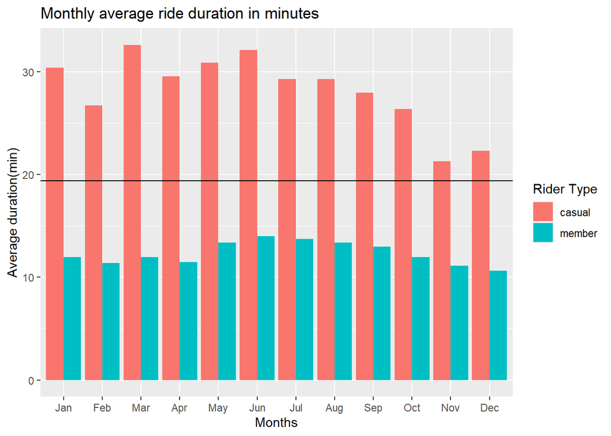

```r
yearly_trips_v3 %>%
  group_by(member_casual, month) %>%
  summarise(number_of_rides = n(), average_duration=mean(ride_length)) %>%
  arrange(member_casual,month) %>%
  ggplot(aes(x=month, y=average_duration, fill= member_casual))+
  geom_col(position = "dodge")+
  geom_hline(yintercept = 19.4)+
  xlab("Months")+
  scale_x_discrete(labels = c("Jan","Feb","Mar","Apr","May","Jun","Jul","Aug",
                              "Sep","Oct","Nov","Dec"))+
  ylab("Average duration(min)")+
  labs(title = "Monthly average ride duration in minutes" , fill ="Rider Type")
```

The plot shows that casuals tends to ride longer than members, and members ride duration is below average ride duration.

- If we look at weekly average ride duration

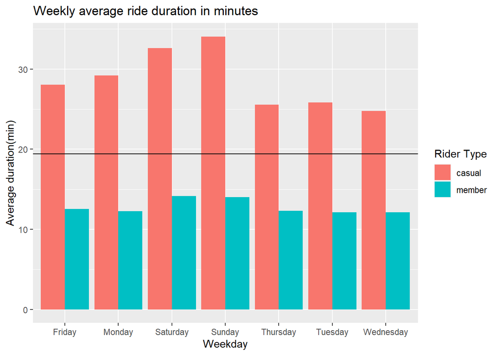

```r
yearly_trips_v3 %>%
  group_by(member_casual, day_of_week) %>%
  summarise(number_of_rides = n(), average_duration=mean(ride_length)) %>%
  arrange(member_casual,day_of_week) %>%
  ggplot(aes(x=day_of_week, y=average_duration, fill= member_casual))+
  geom_col(position = "dodge")+
  geom_hline(yintercept = 19.4)+
  xlab("Weekday")+
  ylab("Average duration(min)")+
  labs(title = "Weekly average ride duration in minutes" , fill ="Rider Type")
```

Days aren’t ordered to fix it

```r
yearly_trips_v3$day_of_week <- ordered(yearly_trips_v3$day_of_week, levels=
                                         c("Monday","Tuesday", "Wednesday",
                                           "Thursday", "Friday", "Saturday",
                                           "Sunday"))
```

After fixing it

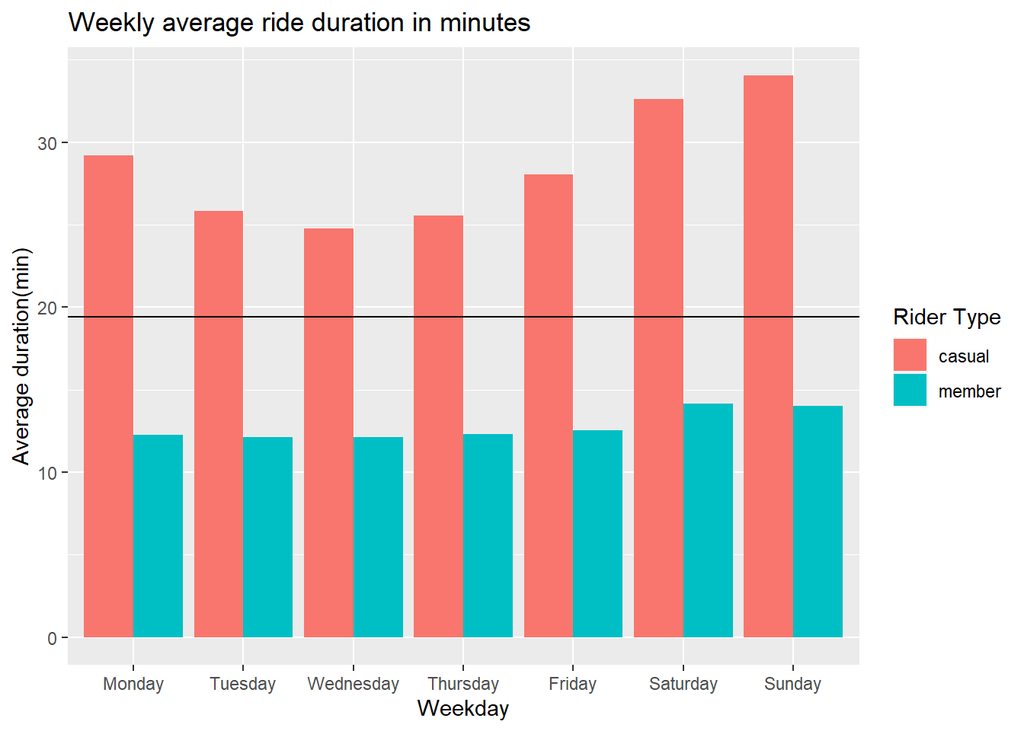

```r
yearly_trips_v3 %>%
  group_by(member_casual, day_of_week) %>%
  summarise(number_of_rides = n(), average_duration=mean(ride_length)) %>%
  arrange(member_casual,day_of_week) %>%
  ggplot(aes(x=day_of_week, y=average_duration, fill= member_casual))+
  geom_col(position = "dodge")+
  geom_hline(yintercept = 19.4)+
  xlab("Weekday")+
  ylab("Average duration(min)")+
  labs(title = "Weekly average ride duration in minutes" , fill ="Rider Type")
```

##### Number of rides

- Lets look at yearly trips.

```r
yearly_trips_v3 %>%
  summarise(number_of_rides = n())
```

```
##   number_of_rides
## 1         5667186
```

This year total of 5.667.186 trips made by our members and casuals.

- If we look at our monthly trips.

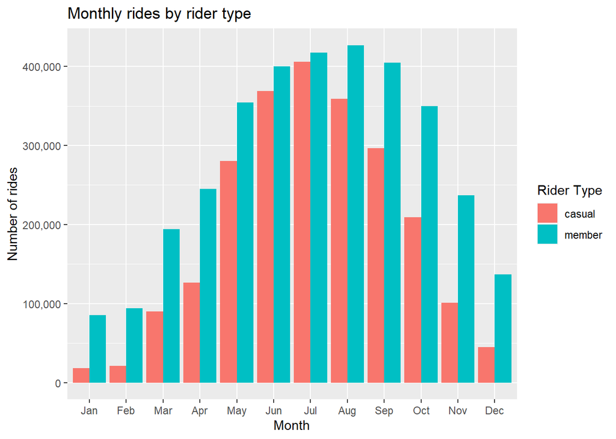

```r
yearly_trips_v3 %>%
  group_by(month, member_casual) %>%
  summarise(number_of_rides = n()) %>%
  ggplot(aes(x=month,y=number_of_rides, fill=member_casual))+
  geom_col(position = "dodge")+
  xlab("Month")+
  scale_x_discrete(labels = c("Jan","Feb","Mar","Apr","May","Jun","Jul","Aug",
                              "Sep","Oct","Nov","Dec"))+
  ylab("Number of rides")+
  scale_y_continuous(labels = comma)+
  labs(title="Monthly rides by rider type", fill= "Rider Type")
```

From the plot we can see that casuals tends to rent more bike in summer.

- If we look at weekly trips.

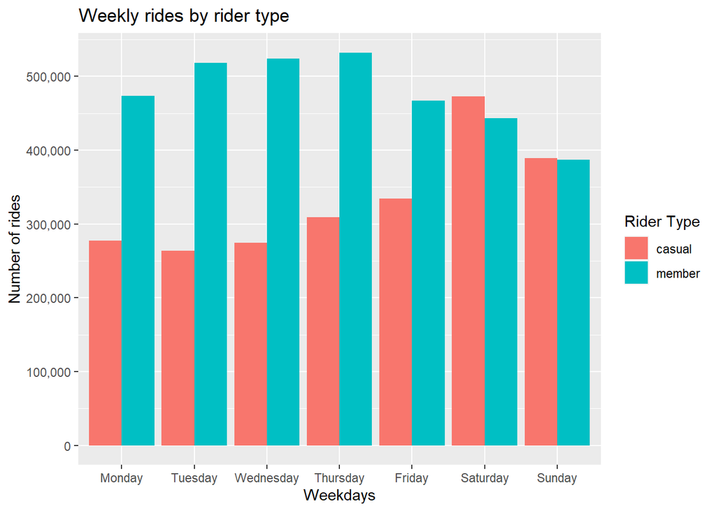

```r
yearly_trips_v3 %>%
  group_by(day_of_week, member_casual) %>%
  summarise(rider_count = n()) %>%
  ggplot(aes(x=day_of_week,y=rider_count, fill=member_casual))+
  geom_col(position = "dodge")+
  xlab("Weekdays")+
  ylab("Number of rides")+
  scale_y_continuous(labels = comma, breaks = seq(0,500000, by =100000))+
  labs(title="Weekly rides by rider type", fill= "Rider Type")
```

In contrast to ride duration our members rent more bike and casual rent more bike at weekends.

## Share Phase

After the analysis:

- Casuals ride longer than members.
- Members rent more bike than casuals.
- Casuals tend to rent more bike in summer and weekends.

## Recommendations

- A discount campaign can be launched for membership in the summer since the casual usage rate increases.